# matplotlib基本使用

```python
import pandas as pd
import numpy as np
```

# matplotlib基本使用

matplotlib.pyplot包含了一系列类似于matlab的画图函数。

```python
import matplotlib.pyplot as plt

# 显示中文标签
plt.rcParams['font.sans-serif'] = ['SimHei']
plt.rcParams['axes.unicode_minus'] = False

# 省略plt.show()
%matplotlib inline
```

图形绘制流程：

- 1. 创建画布 -- plt.figure(figszie,dpi)
     - figsize: 指定图的长宽，单位是英寸
     - dpi：图像的清晰度，每英寸的像素点
- 1. 绘制图像 -- plt.plot(x,y)
- 1. 添加辅助信息
     - 添加x,y轴刻度： plt.xticks(),plt.yticks()
     - 添加网格显示：plt.grid()
     - 添加轴和标题：plt.xlabel(),plt.ylabel(),plt.title()
     - 添加注释文本：plt.annotate()
     - 添加图例：plt.legend()
- 1. 保存图像（可选） -- plt.savefig()
- 1. 显示图像 -- plt.show()
     - 注意：当写入 %matplotlib inline 后，可不写plt.show()

## 1 画出初始折线图

为了更好地理解所有基础绘图功能，我们通过天气温度变化的绘图来融合所有的基础API使用

需求：画出某城市11点到12点，1小时内每分钟的温度变化折线图，温度范围在15度~18度

效果：

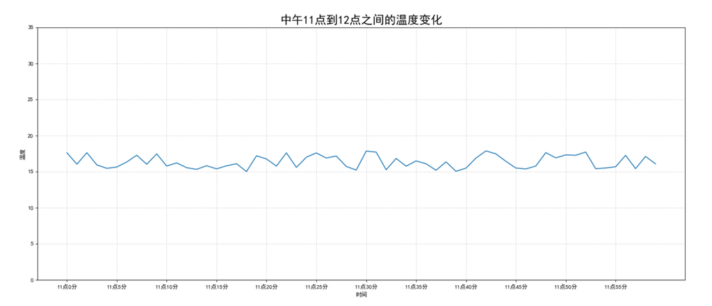

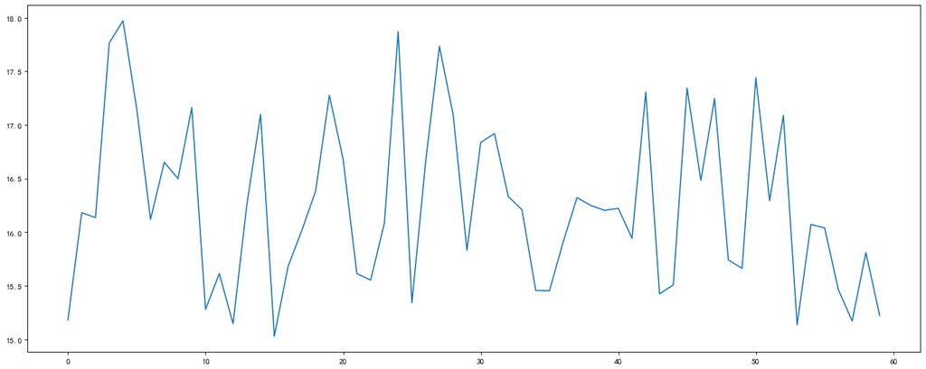

```python
# 准备x,y坐标轴数据
x = range(60)
y_shanghai = [np.random.uniform(15, 18) for _ in x]

# 创建画布
plt.figure(figsize=(20, 8), dpi=80)

# 绘制折线图
plt.plot(x, y_shanghai)
```

- 这时候我们我们想要添加x,y轴刻度，使得数据表示更加清晰。

## 2 添加自定义x，y刻度

- plt.xticks(x, **kwargs)
  - x:要显示的刻度值
- plt.yticks(y, **kwargs)
  - y:要显示的刻度值
- 注意：当填入空的列表，则去掉坐标值刻度
  - 例如：plt.xticks([])

```
 <a list of 8 Text yticklabel objects>)
```

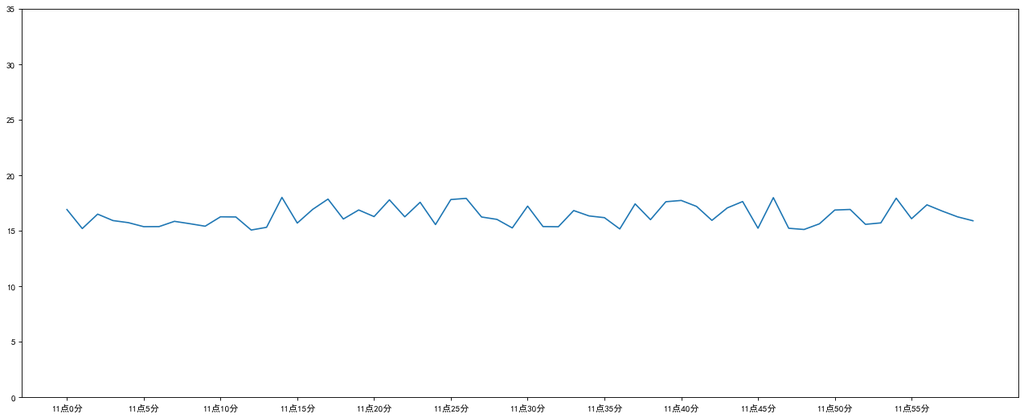

```python
# 准备x,y坐标轴数据
x = range(60)
y_shanghai = [np.random.uniform(15, 18) for _ in x]

# 创建画布
plt.figure(figsize=(20, 8), dpi=80)

# 绘制折线图
plt.plot(x, y_shanghai)

##################### New code #########################

# 构造x轴刻度标签
x_ticks_label = ['11点{}分'.format(i) for i in x]

# 构造y轴刻度标签
y_ticks = range(40)

# 修改x,y轴左表的刻度显示
plt.xticks(x[::5], x_ticks_label[::5])
plt.yticks(y_ticks[::5])

##################### New code #########################
```

- 这时候我们发现值不太好好观察，所以为了更加清除地观察图形对应的值，需要添加网格显示。

## 3 添加网格显示

- plt.grid(b=True, linestyle='--', alpha=0.5)
  - b: True 表示显示网格grid
  - linestyle：线条格式,常见的如下：
    - '-': 实线
    - '--': 虚线
  - alpha: 透明度

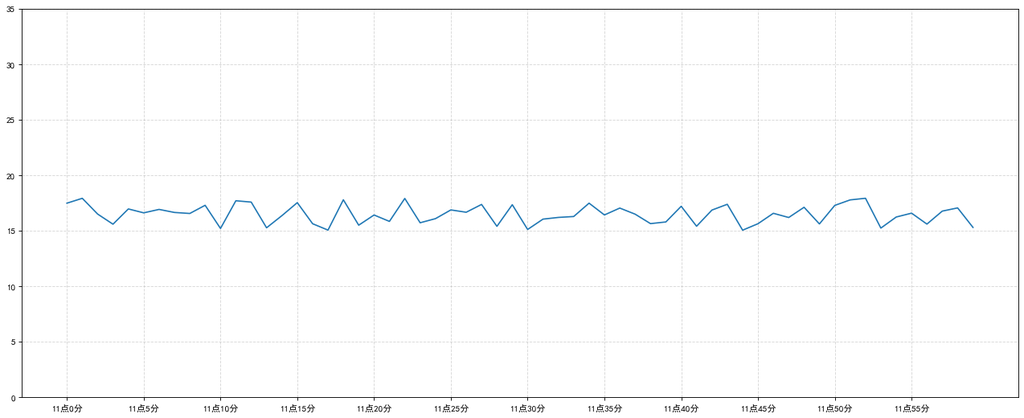

```python
# 准备x,y坐标轴数据
x = range(60)
y_shanghai = [np.random.uniform(15, 18) for _ in x]

# 创建画布
plt.figure(figsize=(20, 8), dpi=80)

# 绘制折线图
plt.plot(x, y_shanghai)

# 构造x轴刻度标签
x_ticks_label = ['11点{}分'.format(i) for i in x]

# 构造y轴刻度标签
y_ticks = range(40)

# 修改x,y轴左表的刻度显示
plt.xticks(x[::5], x_ticks_label[::5])
plt.yticks(y_ticks[::5])

##################### New code #########################

# 添加网格显示
plt.grid(True, linestyle='--', alpha=0.5)

##################### New code #########################
```

- 这时候我们想要添加一些描述信息，比如x，y轴和标题

## 4 添加轴和标题

- plt.xlabel()：添加x轴
- plt.ylabel()：添加y轴
- plt.title():添加标题

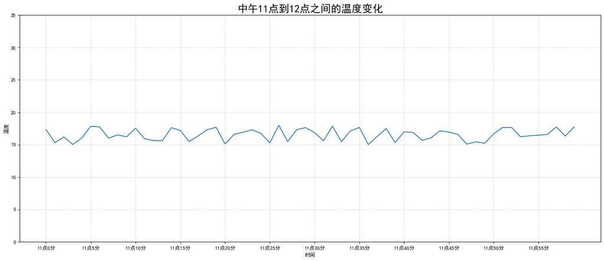

```python
# 准备x,y坐标轴数据
x = range(60)
y_shanghai = [np.random.uniform(15, 18) for _ in x]

# 创建画布
plt.figure(figsize=(20, 8), dpi=80)

# 绘制折线图
plt.plot(x, y_shanghai)

# 构造x轴刻度标签
x_ticks_label = ['11点{}分'.format(i) for i in x]

# 构造y轴刻度标签
y_ticks = range(40)

# 修改x,y轴左表的刻度显示
plt.xticks(x[::5], x_ticks_label[::5])
plt.yticks(y_ticks[::5])

# 添加网格显示
plt.grid(True, linestyle='--', alpha=0.5)

##################### New code #########################

# 添加x，y轴和标题
plt.xlabel('时间')
plt.ylabel('温度')
plt.title('中午11点到12点之间的温度变化', fontsize=20)

##################### New code #########################
```

## 5 添加注释文本

有时候需要在图形中的某个点标记或者注释一下。那么我们可以使用plt.annotate()来实现。

- plt.annotate(text,xy,xytext,arrowprops={})
  - text: 注释的文本
  - xy： 是需要注释的点坐标
  - xytext: 是注释文本的坐标
  - arrowprops： 是箭头的样式属性

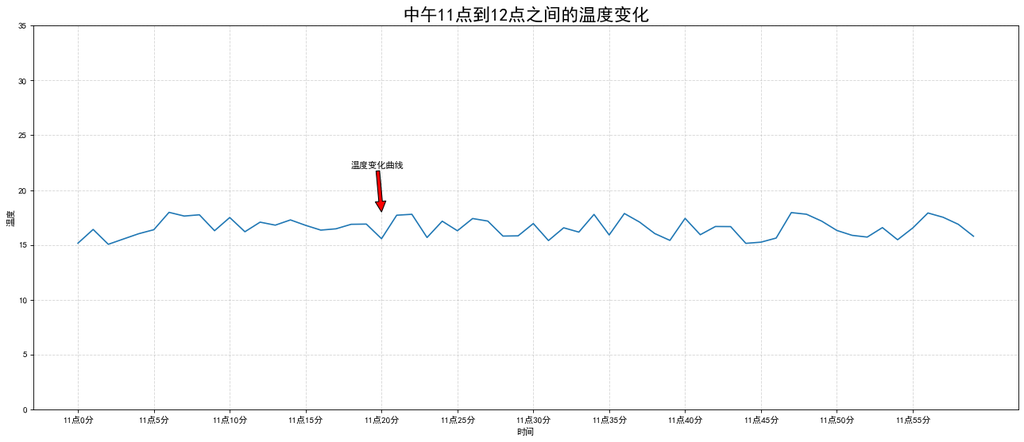

```python
# 准备x,y坐标轴数据
x = range(60)
y_shanghai = [np.random.uniform(15, 18) for _ in x]

# 创建画布
plt.figure(figsize=(20, 8), dpi=80)

# 绘制折线图
plt.plot(x, y_shanghai)

# 构造x轴刻度标签
x_ticks_label = ['11点{}分'.format(i) for i in x]

# 构造y轴刻度标签
y_ticks = range(40)

# 修改x,y轴左表的刻度显示
plt.xticks(x[::5], x_ticks_label[::5])
plt.yticks(y_ticks[::5])

# 添加网格显示
plt.grid(True, linestyle='--', alpha=0.5)

# 添加x，y轴和标题
plt.xlabel('时间')
plt.ylabel('温度')
plt.title('中午11点到12点之间的温度变化', fontsize=20)

##################### New code #########################

# 添加注释
plt.annotate('温度变化曲线', xy=(20, 18), xytext=(18, 22),
             arrowprops=dict(facecolor='red'))

##################### New code #########################
```

## 6 图像保存

- plt.savefig(path)

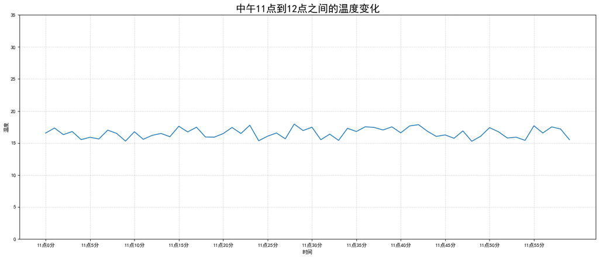

```python
# 准备x,y坐标轴数据
x = range(60)
y_shanghai = [np.random.uniform(15, 18) for _ in x]

# 创建画布
plt.figure(figsize=(20, 8), dpi=80)

# 绘制折线图
plt.plot(x, y_shanghai)

# 构造x轴刻度标签
x_ticks_label = ['11点{}分'.format(i) for i in x]

# 构造y轴刻度标签
y_ticks = range(40)

# 修改x,y轴左表的刻度显示
plt.xticks(x[::5], x_ticks_label[::5])
plt.yticks(y_ticks[::5])

# 添加网格显示
plt.grid(True, linestyle='--', alpha=0.5)

# 添加x，y轴和标题
plt.xlabel('时间')
plt.ylabel('温度')
plt.title('中午11点到12点之间的温度变化', fontsize=20)

##################### New code #########################

# 保存图片
plt.savefig('../data/sample1.png')

##################### New code #########################
```

## 7 一个坐标系中绘制多个图像

需求：再添加一个城市的温度变化

收集到北京当天温度变化情况，温度在1度到3度。怎么去添加另一个在同一坐标系当中的不同图形，其实很简单只需要再次plot即可，但是需要区分线条，比如用颜色，线条格式来区分。

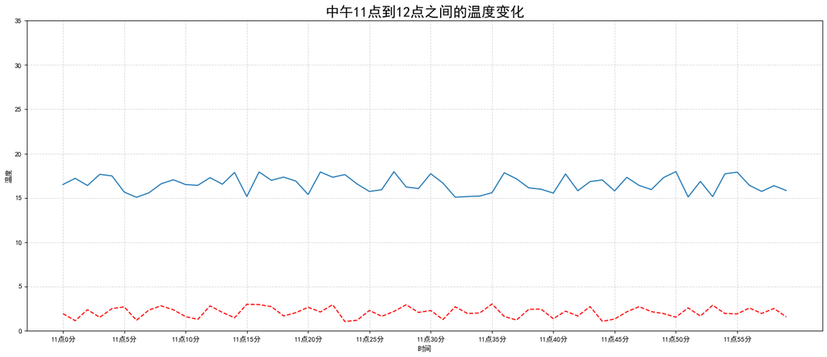

```python
# 准备x,y坐标轴数据
x = range(60)
y_shanghai = [np.random.uniform(15, 18) for _ in x]

##################### New code #########################

# 添加北京的温度数据
y_beijing = [np.random.uniform(1, 3) for _ in x]

##################### New code #########################

# 创建画布
plt.figure(figsize=(20, 8), dpi=80)

# 绘制上海折线图
plt.plot(x, y_shanghai)

##################### New code #########################

# 绘制北京折线图
plt.plot(x, y_beijing, color='r', linestyle='--')

##################### New code #########################

# 构造x轴刻度标签
x_ticks_label = ['11点{}分'.format(i) for i in x]

# 构造y轴刻度标签
y_ticks = range(40)

# 修改x,y轴左表的刻度显示
plt.xticks(x[::5], x_ticks_label[::5])
plt.yticks(y_ticks[::5])

# 添加网格显示
plt.grid(True, linestyle='--', alpha=0.5)

# 添加x，y轴和标题
plt.xlabel('时间')
plt.ylabel('温度')
plt.title('中午11点到12点之间的温度变化', fontsize=20)
```

## 8 设置图形风格

常见的颜色和字符风格，如下表所示：

| 'color'代码 | 颜色 |
| --- | --- |
| r | 红色 |
| g | 绿色 |
| b | 蓝色 |
| w | 白色 |
| c | 青色 |
| m | 洋红 |
| y | 黄色 |
| k | 黑色 |

| 'linestyle'代码 | 颜色 |
| --- | --- |
| - | 实线 |
| -- | 虚线 |
| -. | 点划线 |
| : | 点虚线 |

## 9 显示图例

现在画出了北京和上海的温度变化图，但是无法区分哪条属于北京，所以需要添加图例。

- plt.legend(loc='best')
  - loc: 图例的显示位置，'best'是matplotlib自动判断最好的位置

注意：如果只在plt.plot()中设置label还不能最终显示出图例，还需要通过plt.legend()将图例显示出来。

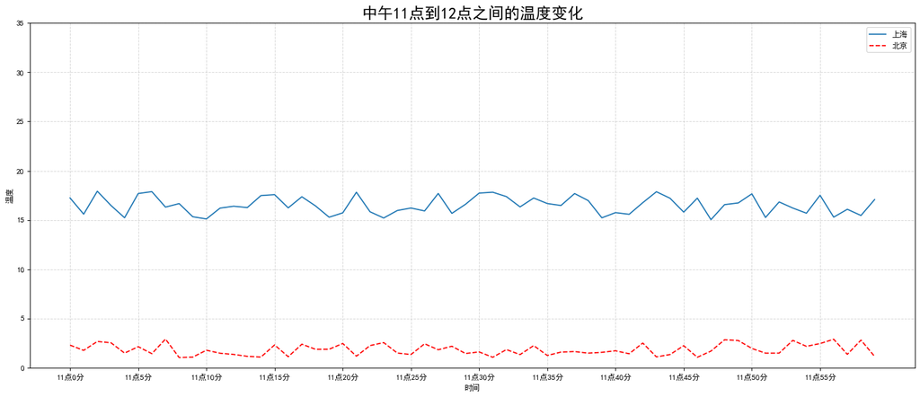

```python
# 准备x,y坐标轴数据
x = range(60)
y_shanghai = [np.random.uniform(15, 18) for _ in x]

# 添加北京的温度数据
y_beijing = [np.random.uniform(1, 3) for _ in x]

# 创建画布
plt.figure(figsize=(20, 8), dpi=80)

##################### New code #########################

# 绘制上海折线图
plt.plot(x, y_shanghai, label='上海')

# 绘制北京折线图
plt.plot(x, y_beijing, color='r', linestyle='--', label='北京')

# 显示图例
plt.legend(loc="best")

##################### New code #########################

# 构造x轴刻度标签
x_ticks_label = ['11点{}分'.format(i) for i in x]

# 构造y轴刻度标签
y_ticks = range(40)

# 修改x,y轴左表的刻度显示
plt.xticks(x[::5], x_ticks_label[::5])
plt.yticks(y_ticks[::5])

# 添加网格显示
plt.grid(True, linestyle='--', alpha=0.5)

# 添加x，y轴和标题
plt.xlabel('时间')
plt.ylabel('温度')
plt.title('中午11点到12点之间的温度变化', fontsize=20)
```

## 10 多个坐标系显示

如果我们想要将上海和北京的天气图显示在同一个图的不同坐标系当中，效果如下：

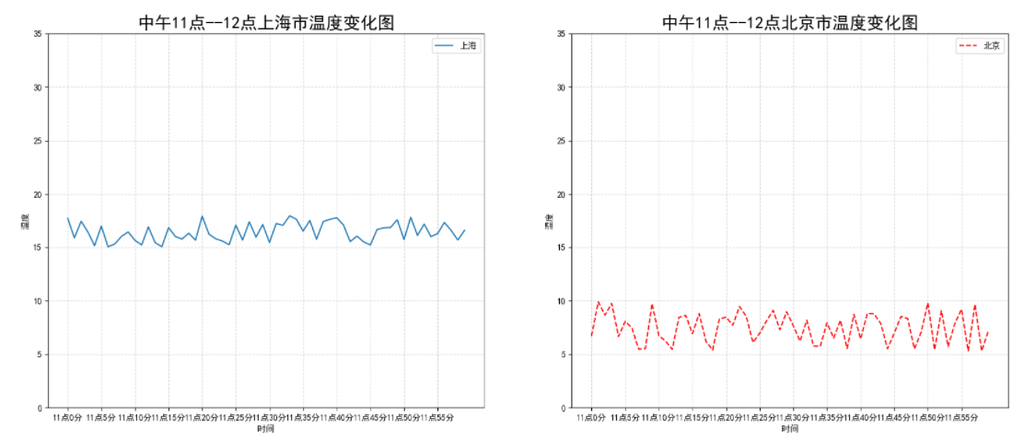

可以通过subplots函数实现：

- plt.subplots(nrows=1, ncols=1, **fig_kw) :创建一个带有多个axes(坐标系/绘图区)的图
  - Parameters：
    - nrows,ncols: 设置有几行几列坐标系
    - **fig_kw：figure的参数设置
  - Returns：
    - fig:图对象
    - axes：返回相应数量的坐标系
  - 设置标题等方法不同：
    - set_xticks
    - set_yticks
    - set_xlabel
    - set_ylabel
- 注：用''' ... '''来注释的是之前只有一个坐标轴的写法,可以和现在多子图的写法进行对比。

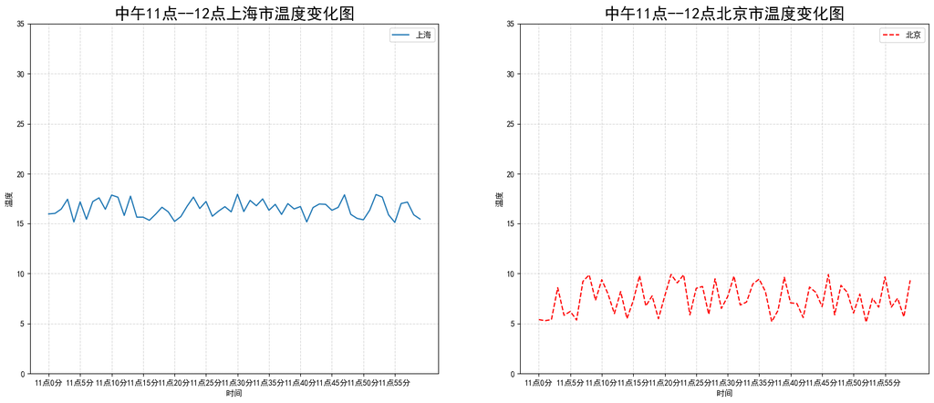

```python
# 准备x,y坐标轴数据
x = range(60)
y_shanghai = [np.random.uniform(15, 18) for _ in x]
y_beijing = [np.random.uniform(5, 10) for _ in x]

##################### New code #########################

# 创建画布
'''
plt.figure(figsize=(20,8),dpi=80)
'''
fig, axes = plt.subplots(nrows=1, ncols=2, figsize=(20, 8), dpi=100)

# 绘制上海折线图
'''
plt.plot(x, y_shanghai, label='上海')
'''
axes[0].plot(x, y_shanghai, label="上海")

# 绘制北京折线图
'''
plt.plot(x, y_beijing, color='r',linestyle='--',label='北京')
'''
axes[1].plot(x, y_beijing, color="r", linestyle="--", label="北京")

# 构造x轴刻度标签
x_ticks_label = ['11点{}分'.format(i) for i in x]

# 构造y轴刻度标签
y_ticks = range(40)

# 设置上海和北京的xy轴刻度
'''
plt.xticks(x[::5], x_ticks_label[::5])
plt.yticks(y_ticks[::5])
'''
axes[0].set_xticks(x[::5])
axes[0].set_yticks(y_ticks[::5])
axes[0].set_xticklabels(x_ticks_label[::5])
axes[1].set_xticks(x[::5])
axes[1].set_yticks(y_ticks[::5])
axes[1].set_xticklabels(x_ticks_label[::5])

# 添加网格显示
'''
plt.grid(True, linestyle='--', alpha=0.5)
'''
axes[0].grid(True, linestyle="--", alpha=0.5)
axes[1].grid(True, linestyle="--", alpha=0.5)

# 添加x，y轴和标题
'''
plt.xlabel('时间')
plt.ylabel('温度')
plt.title('中午11点到12点之间的温度变化',fontsize=20)

'''
axes[0].set_xlabel("时间")
axes[0].set_ylabel("温度")
axes[0].set_title("中午11点--12点上海市温度变化图", fontsize=20)
axes[1].set_xlabel("时间")
axes[1].set_ylabel("温度")
axes[1].set_title("中午11点--12点北京市温度变化图", fontsize=20)

# 显示图例
'''
plt.legend(loc='best')'
'''
axes[0].legend(loc='best')
axes[1].legend(loc='best')

##################### New code #########################
```

## 11 matplotlib 配置

### 11.1 画布风格设置

- matplotlib图片默认内置了几种画布风格。我们可以通过plt.style.available来查看内置的所有风格:

```python
plt.style.available
```

```
['bmh',
 'classic',
 'dark_background',
 'fast',
 'fivethirtyeight',
 'ggplot',
 'grayscale',
 'seaborn-bright',
 'seaborn-colorblind',
 'seaborn-dark-palette',
 'seaborn-dark',
 'seaborn-darkgrid',
 'seaborn-deep',
 'seaborn-muted',
 'seaborn-notebook',
 'seaborn-paper',
 'seaborn-pastel',
 'seaborn-poster',
 'seaborn-talk',
 'seaborn-ticks',
 'seaborn-white',
 'seaborn-whitegrid',
 'seaborn',
 'Solarize_Light2',
 'tableau-colorblind10',
 '_classic_test']
```

- 在绘制的，可以使用plt.style.use方法来使用不同的风格。示例代码如下：

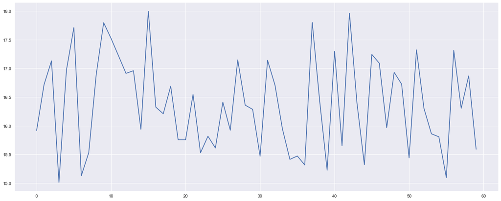

```python
# 设置不同的风格
plt.style.use("seaborn")

# 准备x,y坐标轴数据
x = range(60)
y = [np.random.uniform(15, 18) for _ in x]

# 创建画布，并绘制折线图
plt.figure(figsize=(20, 8), dpi=80)
plt.plot(x, y)
```

### 11.2 修改默认的配置

- 修改默认的配置可以通过matplotlib.rcParams来设置，比如修改字体，修改线条大小和宽度等。示例代码如下：

```python
# 设置字体为仿宋
plt.rcParams['font.sans-serif'] = ['SimHei']

# 正常显示负号
plt.rcParams['axes.unicode_minus'] = False

# 设置字体大小为20
plt.rcParams['font.size'] = 20

# 设置线条宽度
plt.rcParams['lines.linewidth'] = 2
```

- 常见的配置显示如下表：

| plt.rcParams参数 | 描述 |
| --- | --- |
| figure.figsize | 调整生成的图标尺寸 |
| figure.dpi | 设置每英寸像素点 |
| font.sans-serif | 设置字体 |
| font.size | 字体大小 |
| hist.bins | 直方图分箱个数 |
| lines.linewidth | 线宽 |
| lines.marker | 标记样式 |
| savefig.fomrat | 保存图片的格式 |
| savefig.jpeg_quality | 图片质量 |
| text.color | 文本颜色 |
| timezone | 失去格式 |

## 12 matplotlib使用小技巧

### 12.1 可以对图像进行填充 -- fill_between

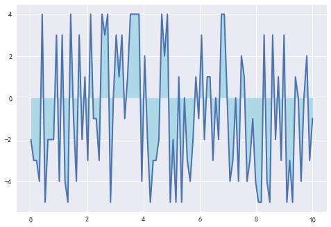

```python
# 获取数据
x = np.linspace(0, 10, 100)
y = np.random.randint(-5, 5, 100)

# 创建画布
fig, axes = plt.subplots()

# 绘制折线图
axes.plot(x, y)

# 填充折线与x轴的面积
axes.fill_between(x, y, color='lightblue')
```

### 12.2 对x轴或y轴的刻度进行旋转

有时可能会出现x轴的坐标刻度重合的情况，可以对x轴的坐标刻度进行旋转,添加参数rotation设置旋转角度。

```
 <a list of 20 Text xticklabel objects>)
```

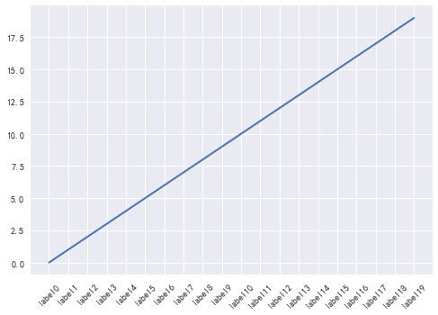

```python
# 获取数据
x = range(20)
y = range(20)

# 构建x轴刻度
labels = ['label{}'.format(i) for i in range(20)]

# 创建画布并进行绘制折线图
fig = plt.figure()
plt.plot(x, y)

# 添加x轴刻度,旋转45度
plt.xticks(x, labels, rotation=45)
```

### 12.3 把图例放到图外显示

如果想要把图例放到图外，可以设置bbox_to_anchor参数，内容为坐标，可以进行调整。

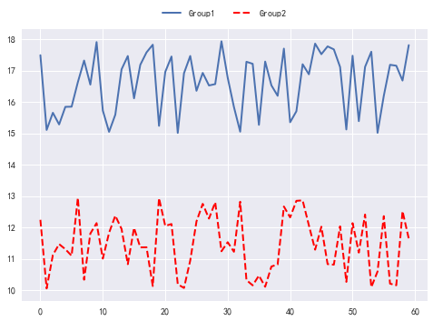

```python
x = range(60)
y1 = [np.random.uniform(15, 18) for _ in x]
y2 = [np.random.uniform(10, 13) for _ in x]

# 创建画布和子图
fig, ax = plt.subplots()

# 绘制折线图，表明label
ax.plot(x, y1, label='Group1')
ax.plot(x, y2, color='r', linestyle='--', label='Group2')

# 显示图例，并在图外显示
ax.legend(loc='upper center', bbox_to_anchor=(0.5, 1.1), ncol=2)
```